# Cyclistic bike analysis between annual members and casual riders

#Cyclistic bike use difference between annual members and casual riders

##1. Business Task Identify the bike use difference between annual members and casual riders to build a marketing strategy aimed at converting casual riders into annual members

##2. Prepare Data ###Data Source The data for this analysis is collected by Cyclistic in the terms from September 2021 to August 2022.

###Import data

```r
library(tidyverse)
library(lubridate)
```

```r
library(ggplot2)

getwd()
```

```
## [1] "C:/Users/User/Documents/Cyclistic_case_study/tripdata"
```

```r
setwd("/Users/User/Documents/Cyclistic_case_study/tripdata")

sep_2021 <- read_csv("202109-divvy-tripdata.csv")
oct_2021 <- read_csv("202110-divvy-tripdata.csv")
nov_2021 <- read_csv("202111-divvy-tripdata.csv")
dec_2021 <- read_csv("202112-divvy-tripdata.csv")
jan_2022 <- read_csv("202201-divvy-tripdata.csv")
feb_2022 <- read_csv("202202-divvy-tripdata.csv")
mar_2022 <- read_csv("202203-divvy-tripdata.csv")
apr_2022 <- read_csv("202204-divvy-tripdata.csv")
may_2022 <- read_csv("202205-divvy-tripdata.csv")
jun_2022 <- read_csv("202206-divvy-tripdata.csv")
jul_2022 <- read_csv("202207-divvy-tripdata.csv")
aug_2022 <- read_csv("202208-divvy-tripdata.csv")
##merge the monthly datasets into a single dataset
all_trips <- bind_rows(sep_2021, oct_2021, nov_2021, dec_2021, jan_2022, feb_2022, mar_2022, apr_2022, may_2022, jun_2022, jul_2022, aug_2022)
```

##3. Process data

###Sort out meaningful data(columns) for analysis

```r
all_trips <-  all_trips %>%
  select(-c(start_lat, start_lng, end_lat, end_lng))
```

###Add new columns and convert datetime data into date data to inspect by months and weekdays

```r
all_trips$date <- as.Date(all_trips$started_at)
all_trips$month <- format(as.Date(all_trips$date), "%m")
all_trips$day <- format(as.Date(all_trips$date), "%d")
all_trips$year <- format(as.Date(all_trips$date), "%Y")
all_trips$day_of_week <- format(as.Date(all_trips$date),"%A")
```

###Calculate ride_length and format it to numeric value

```r
all_trips$ride_length <- difftime(all_trips$ended_at, all_trips$started_at)
all_trips$ride_length <- as.numeric(as.character(all_trips$ride_length))

##Make sure there's no bad data
##1. Remove wrong data
all_trips_v2 <- all_trips[!(all_trips$ride_length<0),]
##2. Arrange in the right order
all_trips_v2$day_of_week<-ordered(all_trips_v2$day_of_week,level=c("Sunday","Monday","Tuesday","Wednesday","Thursday","Friday","Saturday"))
```

##4. Analyze Data

First, we’d like to check if annual members and casual riders have different tendency using cyclistic bikes by day of week, comparing the average duration and number of rides.

### Comparison of the number of rides between annual members and casual riders

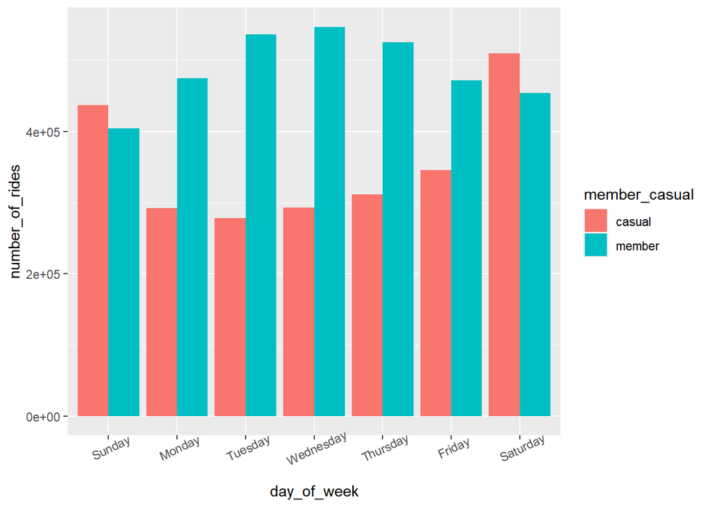

```r
all_trips_v2 %>%
  group_by(member_casual,day_of_week) %>%
  summarize(number_of_rides=n()) %>%
  arrange(member_casual, day_of_week) %>%
  ggplot(aes(x=day_of_week, y=number_of_rides, fill=member_casual))+
  geom_col(position="dodge")+
  theme(axis.text.x = element_text(angle = 25))
```

This bar chart shows that Casual members use Cyclistic bikes more on the weekend, while annual members use less on weekend. We can assume that annual members are likely to use Cyclistic bikes for work.

### Comparison of the average duration of rides between annual members and casual riders

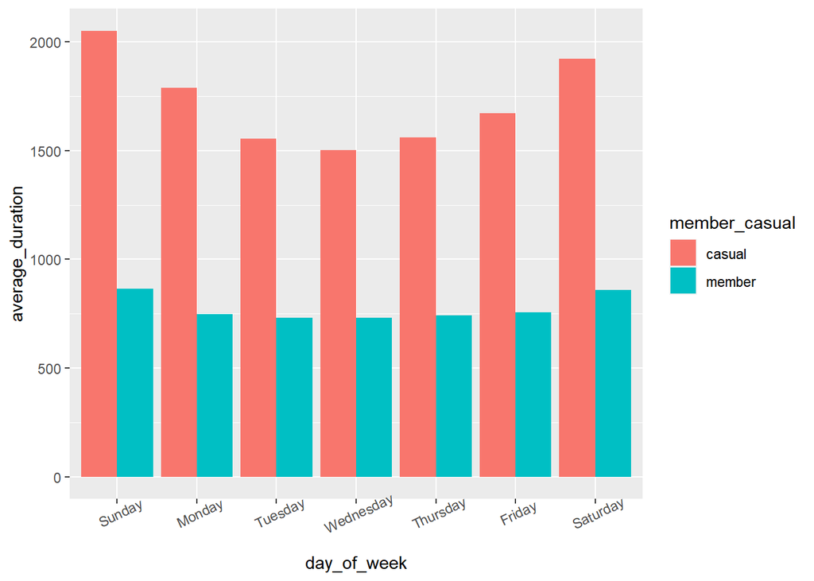

```r
all_trips_v2 %>%
  group_by(member_casual,day_of_week) %>%
  summarize(average_duration=mean(ride_length)) %>%
  arrange(member_casual, day_of_week) %>%
  ggplot(aes(x=day_of_week, y=average_duration, fill=member_casual))+
  geom_col(position="dodge")+
  theme(axis.text.x = element_text(angle = 25))
```

Annual members might use cyclistic bikes more frequently, but ,according to this graph above, casual riders ride almost **double longer** time a ride than annual members. While annual members maintain their riding time no matter what day they ride, casual riders ride longer on weekend than on weekdays.

###Comparison of monthly bike use tendency between annual members and casual riders

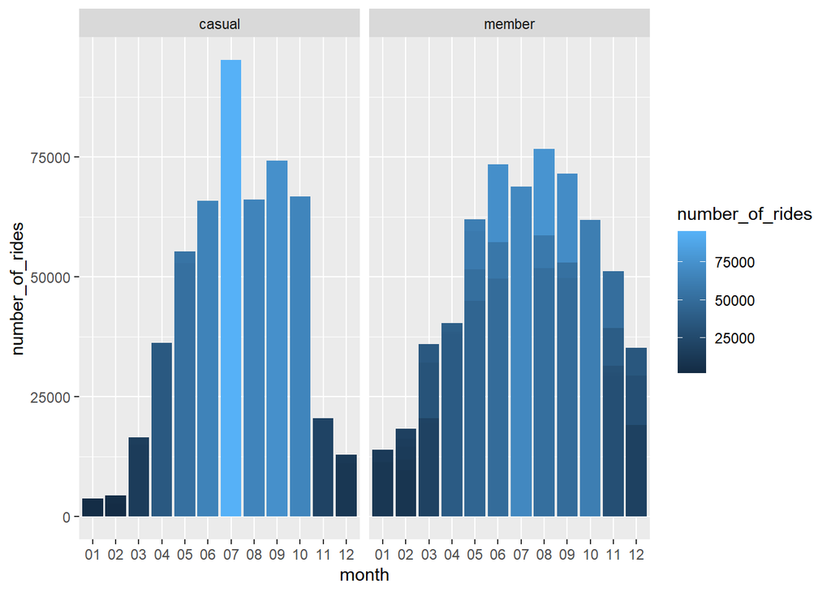

```r
all_trips_v2 %>%
  group_by(member_casual,month,day_of_week) %>%
  summarize(number_of_rides=n(),
            average_duration=mean(ride_length)) %>%
  arrange(member_casual, month, day_of_week) %>%
  ggplot(aes(x=month, y=number_of_rides, fill=number_of_rides))+
  geom_col(position="dodge")+
  facet_wrap(~member_casual)
```

This chart shows that casual riders’ number of rides soars in July, while annual members’ sinks a little. Given that July is in the middle of vacation season, we can assume that casual riders usually ride bikes for hobby. That is explainable also with the number of rides in the winter season from November to February. Compared to annual members, it is remarkable how much the number of rides sink for casual riders in the winter.

##Key Takeaways * #1 Casual riders tend to ride bikes for **hobby** rather than for work. It is important to make Cyclistic’s brandizing in a friendlier way rather than in a technical way. * #2 Casual riders spend **more time** riding bikes, once they take bikes, while members ride bikes short time. Guaranteeing safety and full-charging system could give good impression. * #3 Cyclistic bikes are considered as one of **leisure activity** for casual riders. Targeting the pre-vacation season is a good strategy.